# Confidence Intervals

> More strictly speaking, the confidence level represents the frequency (i.e. the proportion) of possible confidence intervals that contain the true value of the unknown population parameter. In other words, if confidence intervals are constructed using a given confidence level from an infinite number of independent sample statistics, the proportion of those intervals that contain the true value of the parameter will be equal to the confidence level.

- [Wikipedia](https://en.wikipedia.org/wiki/Confidence_interval)

Create a function to compute a confidence interval assuming the population is normally distributed. By default, `sd = NA` and `confidence_level = 0.95`. The function will take a numeric vector `x` and produce a 95% confidence interval using a t-table value (since the population standard deviation is missing) with degrees of freedom equal to the length of `x` - 1.

When the population standard deviation is known and supplied, the calculation will be based on a standard normal table value.

```r
confidence_interval <- function(x, sd = NA, confidence_level = 0.95) {
  alpha <- 1 - confidence_level
  if (!is.na(sd)) {
    table_value <- qnorm(alpha/2, lower.tail = FALSE)
  } else {
    table_value <- qt(alpha/2, df = length(x) - 1, lower.tail = FALSE)
    sd <- sd(x)
  }
  ci <- mean(x) + c(-1, 1) * table_value * sd / sqrt(length(x))
  names(ci) <- c("Lower Bound", "Upper Bound")
  ci
}
```

Now, let’s calculate some confidence intervals on known distributions.

```r
n <- 5
true_mean <- 0

# Define the population - drawing from a standard normal distribution
data <- rnorm(n, true_mean, 1)
data
```

```
[1]  0.3610859 -0.1146811 -1.5709710 -0.7815334 -0.3487668
```

```r
interval <- confidence_interval(data)
interval
```

```
Lower Bound Upper Bound
 -1.3988843   0.4169378
```

This is our confidence interval for the mean of the simulated data we just created. We can check to see if this interval includes the `true_mean`.

```r
interval[1] < true_mean && true_mean < interval[2]
```

```
[1] TRUE
```

Now, let’s run it again!

```r
data <- rnorm(n, true_mean, 1)
data
```

```
[1]  0.11862711 -0.04064094 -0.53951558 -0.85458798 -0.10061499
```

```r
interval <- confidence_interval(data)
interval
```

```
Lower Bound Upper Bound
 -0.7822649   0.2155719
```

Why are these confidence intervals different?

### Simulation

Now we’ll simulate thousands of confidence intervals!

```r
n_reps <- 10000
```

#### For Loop

```r
contains <- numeric(n_reps)
intervals <- matrix(NA, nrow = n_reps, ncol = 2)
for (i in 1:n_reps) {
  data <- rnorm(n, true_mean, 1)
  interval <- confidence_interval(data)
  intervals[i,] <- interval
  contains[i] <- interval[1] < true_mean && true_mean < interval[2]
}

coverage <- mean(contains)
coverage
```

```
[1] 0.9507
```

#### Replicate

```r
intervals <- replicate(n_reps, {
  data <- rnorm(n, true_mean, 1)
  confidence_interval(data)
})

contains <- apply(intervals, 2, prod) < 0

coverage <- mean(contains)
coverage
```

```
[1] 0.9511
```

#### Tidyverse

```r
library(tidyverse)

intervals <- rerun(n_reps, confidence_interval(rnorm(n, true_mean)))

contains <- map_lgl(intervals, ~prod(.) < 0)

coverage <- mean(contains)
coverage
```

```
[1] 0.9502
```

Look at that! Close to .95 - illustrating exactly what the definition of a confidence interval refers to. Now, since we arrived at this calculation via a simulation, we can put a confidence interval on our coverage estimate for confidence intervals. Now, note that in this case we’re creating a confidence interval for a proportion:

$$p \pm Z_\alpha \sqrt{\frac{p(1-p)}{N}}$$

```r
coverage + c(-1, 1) * qnorm(0.975) * sqrt(coverage * (1 - coverage)/n_reps)
```

[output not shown]

Now let’s get some visual intuition behind this:

[output not shown]

[output cut: 990 more lines]

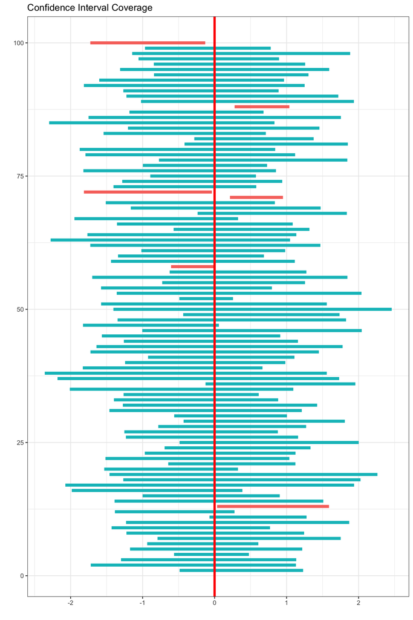

```r
ggplot(head(intervals_df, 100), aes(x = lower, xend = upper, y = index, yend = index)) +
  geom_segment(lineend = "butt", aes(col = includes), show.legend = FALSE, lwd = 2) +
  geom_vline(xintercept = true_mean, col = "red", lwd = 1.5) +
  theme_bw() +
  labs(title = "Confidence Interval Coverage",
       x = "",
       y = "")
```

### Expand the simulation

[output not shown]

[output not shown]

[output not shown]

[output not shown]